# Numerical data analysis using R

Dr. Wan Nor Arifin

Updated: 15 December 2025

# 1 Two independent samples - Independent *t*-test

## 1.1 About the test:

- Parametric test.
- Normally distributed data per group.
- Comparison of means between TWO groups.
- *t*-statistics.

## 1.2 Analysis:

1. Load `cholest.sav` dataset,

```r
library(foreign)
cholest = read.spss("cholest.sav", to.data.frame = T)
str(cholest)
```

```
#> 'data.frame':    80 obs. of  5 variables:
#>  $ chol    : num  6.5 6.6 6.8 6.8 6.9 7 7 7.2 7.2 7.2 ...
#>  $ age     : num  38 35 39 36 31 38 33 36 40 34 ...
#>  $ exercise: num  6 5 6 5 4 4 5 5 4 6 ...
#>  $ sex     : Factor w/ 2 levels "female","male": 2 2 2 2 2 2 2 2 2 2 ...
#>  $ categ   : Factor w/ 3 levels "Grp A","Grp B",..: 1 1 1 1 1 1 1 1 1 1 ...
#>  - attr(*, "variable.labels")= Named chr [1:5] "cholesterol in mmol/L" "age in year" "duration of exercise (hours/week)" "" ...
#>   ..- attr(*, "names")= chr [1:5] "chol" "age" "exercise" "sex" ...
#>  - attr(*, "codepage")= int 65001
```

```r
head(cholest)
```

```
#>   chol age exercise  sex categ
#> 1  6.5  38        6 male Grp A
#> 2  6.6  35        5 male Grp A
#> 3  6.8  39        6 male Grp A
#> 4  6.8  36        5 male Grp A
#> 5  6.9  31        4 male Grp A
#> 6  7.0  38        4 male Grp A
```

Explore the data. Obtain the basic descriptive statistics. Mean and SD,

```r
by(cholest$chol, cholest$sex, mean)
```

```
#> cholest$sex: female
#> [1] 8.9275
#> ------------------------------------------------------------
#> cholest$sex: male
#> [1] 7.5325
```

```r
by(cholest$chol, cholest$sex, sd)
```

```
#> cholest$sex: female
#> [1] 0.4551627
#> ------------------------------------------------------------
#> cholest$sex: male
#> [1] 0.4687066
```

and the number of subjects per group,

```r
table(cholest$sex)
```

```
#>
#> female   male
#>     40     40
```

2. Check the **normality assumption** of the data by group,

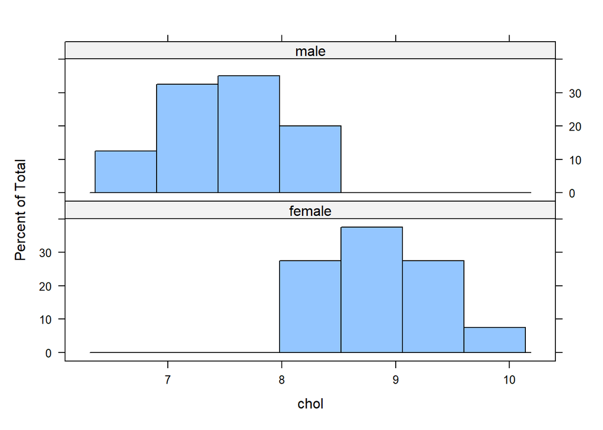

```r
library(lattice)
histogram(~ chol | sex, data = cholest, layout = c(1, 2))
```

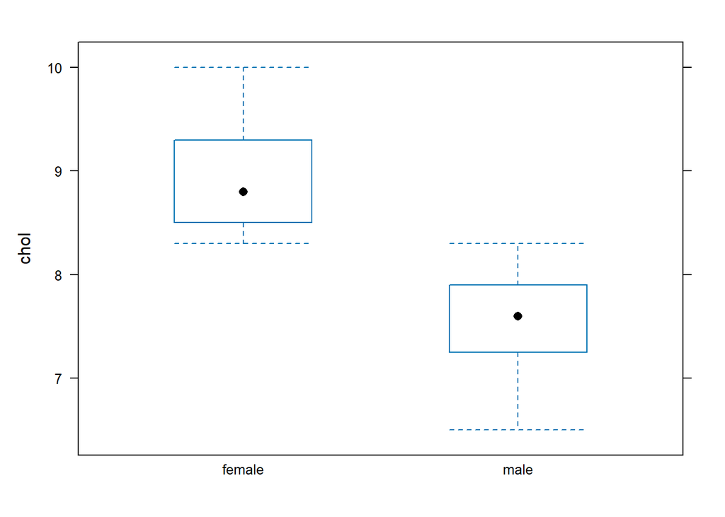

```r
bwplot(chol ~ sex, data = cholest)
```

3. Check the **equality of variance assumption**,

```r
var.test(chol ~ sex, data = cholest)  # equal*
```

```
#>
#>  F test to compare two variances
#>
#> data:  chol by sex
#> F = 0.94304, num df = 39, denom df = 39, p-value = 0.8556
#> alternative hypothesis: true ratio of variances is not equal to 1
#> 95 percent confidence interval:
#>  0.4987744 1.7830278
#> sample estimates:
#> ratio of variances
#>          0.9430422
```

*Choose: - Equal variance = Standard Two Sample *t*-test. - Unequal variance = Welch Two Sample *t*-test. 4. Perform independent *t*-test,

```r
t.test(chol ~ sex, data = cholest)  # significant difference
```

```
#>
#>  Welch Two Sample t-test
#>
#> data:  chol by sex
#> t = 13.504, df = 77.933, p-value < 2.2e-16
#> alternative hypothesis: true difference in means between group female and group male is not equal to 0
#> 95 percent confidence interval:
#>  1.189337 1.600663
#> sample estimates:
#> mean in group female   mean in group male
#>               8.9275               7.5325
```

The function default is **Welch Two Sample *t*-test** (takes car the unequal variance). You can also obtain the standard *t*-test (equal variance assumed),

```r
t.test(chol ~ sex, data = cholest, var.equal = TRUE)
```

```
#>
#>  Two Sample t-test
#>
#> data:  chol by sex
#> t = 13.504, df = 78, p-value < 2.2e-16
#> alternative hypothesis: true difference in means between group female and group male is not equal to 0
#> 95 percent confidence interval:
#>  1.18934 1.60066
#> sample estimates:
#> mean in group female   mean in group male
#>               8.9275               7.5325
```

## 1.3 Presentation

[Guide: Reporting Statistical Results in Medical Journals](http://www.mjms.usm.my/MJMS23052016/01MJMS23052016_ED.pdf)

# 2 Two dependent samples - Paired *t*-test

## 2.1 About the test:

- Parametric test.
- Normally distributed DIFFERENCES between TWO paired observations (e.g. $SBP\ after - SBP\ before$).
- Compares the observations between TWO time points for any changes (e.g. any changes after treatment?).
- If there are changes, the differences between the time points $\neq 0$.
- *t*-statistics.

## 2.2 Analysis:

1. Load `sbp.csv` dataset,

```r
sbp = read.csv("sbp.csv")
str(sbp)
```

```
#> 'data.frame':    11 obs. of  2 variables:
#>  $ S1: int  110 120 120 130 100 120 135 100 140 130 ...
#>  $ S2: int  100 120 130 130 100 130 140 100 140 130 ...
```

```r
sbp
```

```
#>     S1  S2
#> 1  110 100
#> 2  120 120
#> 3  120 130
#> 4  130 130
#> 5  100 100
#> 6  120 130
#> 7  135 140
#> 8  100 100
#> 9  140 140
#> 10 130 130
#> 11 130 130
```

Explore the data. Obtain the basic descriptive statistics. Mean and SD,

```r
mean(sbp$S1); sd(sbp$S1)
```

```
#> [1] 121.3636
```

```
#> [1] 13.43334
```

```r
mean(sbp$S2); sd(sbp$S2)
```

```
#> [1] 122.7273
```

```
#> [1] 15.5505
```

```r
mean(sbp$S2 - sbp$S1); sd(sbp$S2 - sbp$S1)
```

```
#> [1] 1.363636
```

```
#> [1] 5.518564
```

and the number of subjects,

```r
lengths(sbp)
```

```
#> S1 S2
#> 11 11
```

2. Check the **normality assumption** of the differences ($S2-S1$),

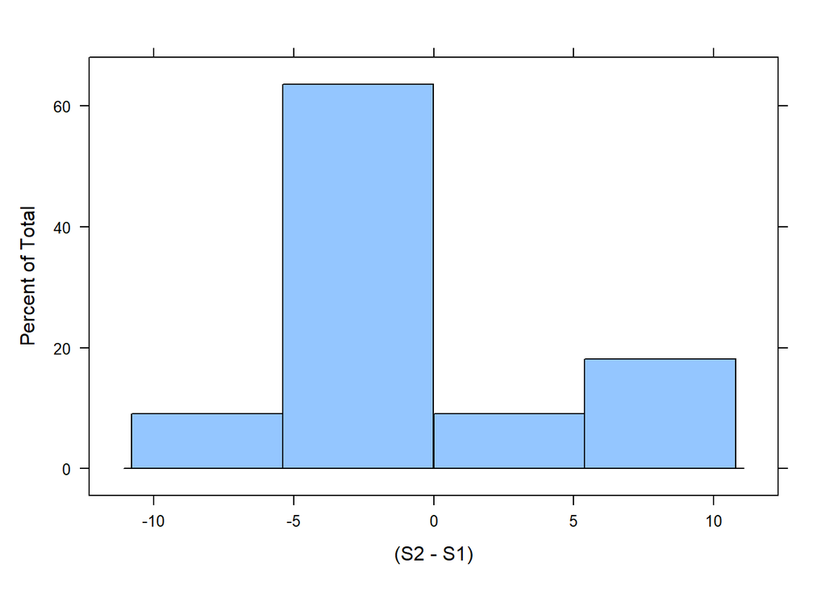

```r
histogram(~ (S2 - S1), data = sbp)  # not perfectly normal
```

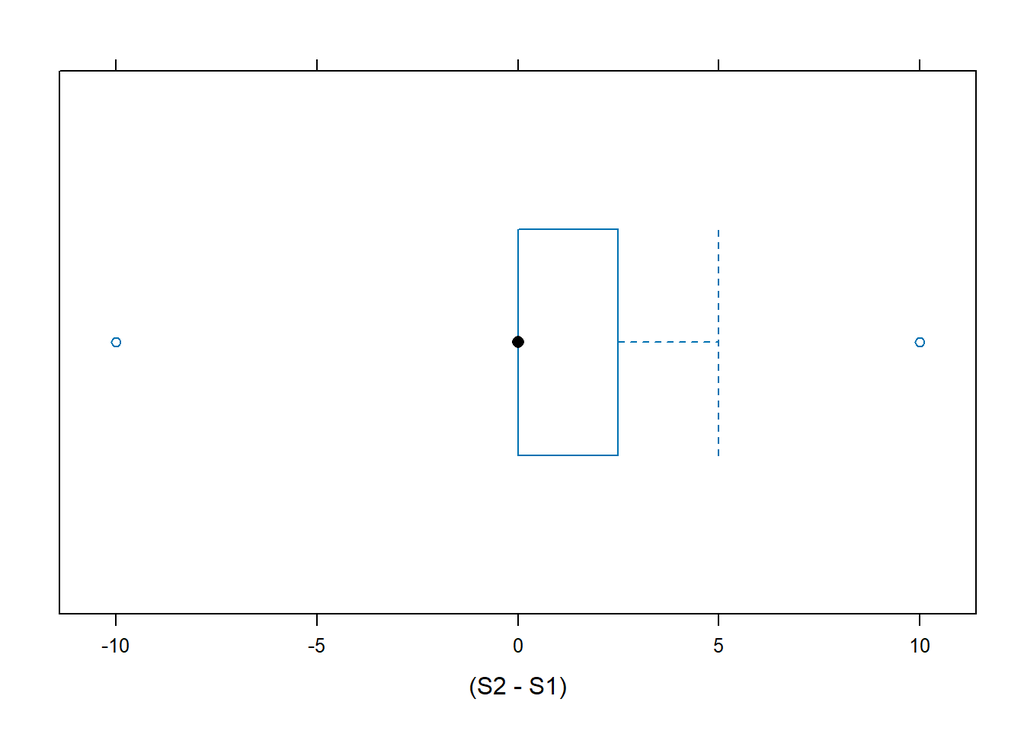

```r
bwplot(~ (S2 - S1), data = sbp)
```

3. Perform paired *t*-test,

```r
t.test(sbp$S1, sbp$S2, paired = TRUE)  # no significant difference
```

```
#>
#>  Paired t-test
#>
#> data:  sbp$S1 and sbp$S2
#> t = -0.81954, df = 10, p-value = 0.4316
#> alternative hypothesis: true mean difference is not equal to 0
#> 95 percent confidence interval:
#>  -5.071058  2.343785
#> sample estimates:
#> mean difference
#>       -1.363636
```

## 2.3 Presentation

[Guide: Reporting Statistical Results in Medical Journals](http://www.mjms.usm.my/MJMS23052016/01MJMS23052016_ED.pdf)

# 3 More than two independent samples - One-way ANOVA

## 3.1 About the test:

- Parametric test.
- Comparison of means for THREE/MORE groups.
- *F*-statistics.

## 3.2 Analysis:

1. Explore the data. Obtain basic descriptive statistics,

```r
by(cholest$chol, cholest$categ, mean)
```

```
#> cholest$categ: Grp A
#> [1] 7.248
#> ------------------------------------------------------------
#> cholest$categ: Grp B
#> [1] 8.293939
#> ------------------------------------------------------------
#> cholest$categ: Grp C
#> [1] 9.25
```

```r
by(cholest$chol, cholest$categ, sd)
```

```
#> cholest$categ: Grp A
#> [1] 0.3355592
#> ------------------------------------------------------------
#> cholest$categ: Grp B
#> [1] 0.3091717
#> ------------------------------------------------------------
#> cholest$categ: Grp C
#> [1] 0.3569047
```

and the number of subjects per group,

```r
table(cholest$categ)
```

```
#>
#> Grp A Grp B Grp C
#>    25    33    22
```

2. Check the **normality assumption** of the data per group,

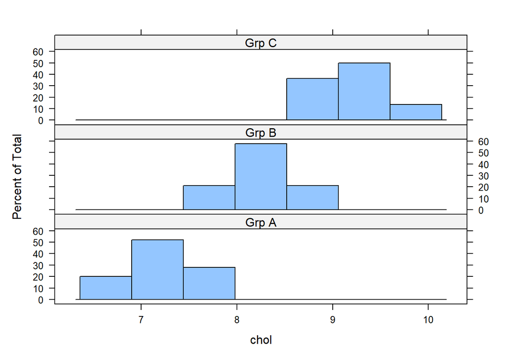

```r
histogram(~ chol | categ, data = cholest, layout = c(1, 3))
```

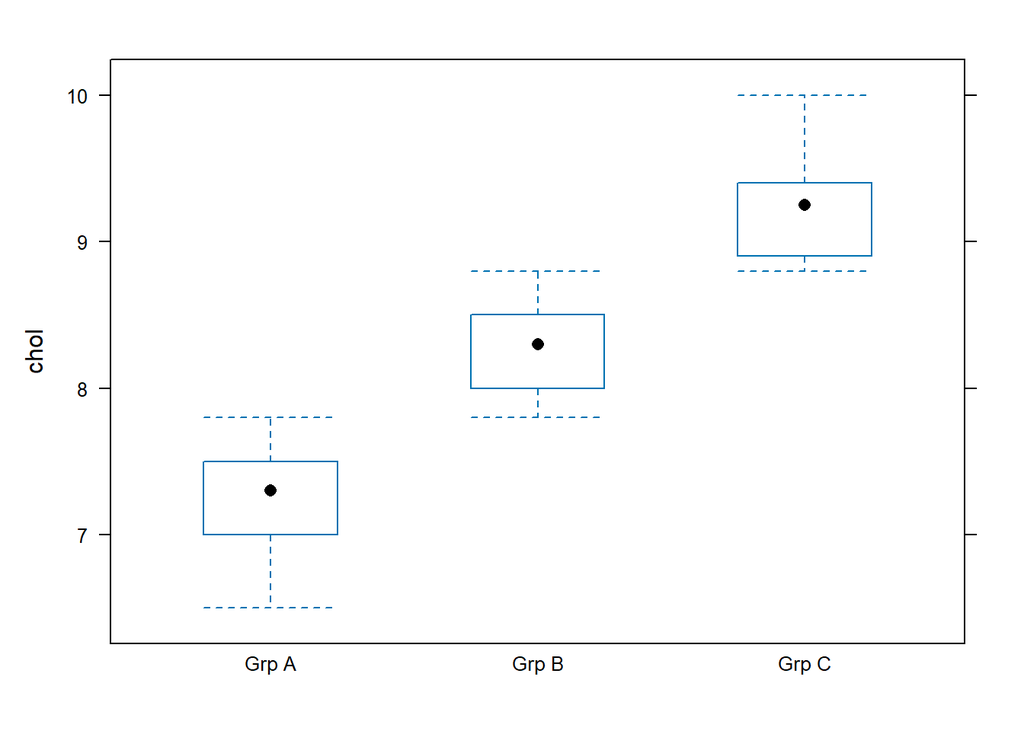

```r
bwplot(chol ~ categ, data = cholest)
```

However, we will mainly rely on **residuals** for the normality assessment. 3. Check the **equality of variance assumption**,

```r
bartlett.test(chol ~ categ, data = cholest)
```

```
#>
#>  Bartlett test of homogeneity of variances
#>
#> data:  chol by categ
#> Bartlett's K-squared = 0.53515, df = 2, p-value = 0.7652
```

4. Perform one-way ANOVA test,

```r
aov_chol = aov(chol ~ categ, data = cholest)
summary(aov_chol)  # significant difference between three groups
```

```
#>             Df Sum Sq Mean Sq F value Pr(>F)
#> categ        2  47.13   23.57   215.1 <2e-16 ***
#> Residuals   77   8.44    0.11
#> ---
#> Signif. codes:  0 '***' 0.001 '**' 0.01 '*' 0.05 '.' 0.1 ' ' 1
```

Notice here we save the output of `aov()` into `aov_chol` first. This allows further extraction of full output from `aov_chol` ANOVA object. 5. Post-hoc test, to look for significant group pairs,

```r
pairwise.t.test(cholest$chol, cholest$categ, p.adj = "bonferroni")
```

```
#>
#>  Pairwise comparisons using t tests with pooled SD
#>
#> data:  cholest$chol and cholest$categ
#>
#>       Grp A  Grp B
#> Grp B <2e-16 -
#> Grp C <2e-16 5e-16
#>
#> P value adjustment method: bonferroni
```

all pairs significant difference Here, it works as if we do multiple independent *t*-tests. We adjust for multiple comparison by Bonferroni correction. 6. Check the **normality of the residuals**, Save the residuals as `residual_chol`. We also need to use `as.numeric()` to extract proper numerical data from `aov_chol` ANOVA object, and save it again to `residuals_chol`

```r
residuals_chol = residuals(aov_chol)
residuals_chol = as.numeric(residuals_chol)
```

Then, check the normality,

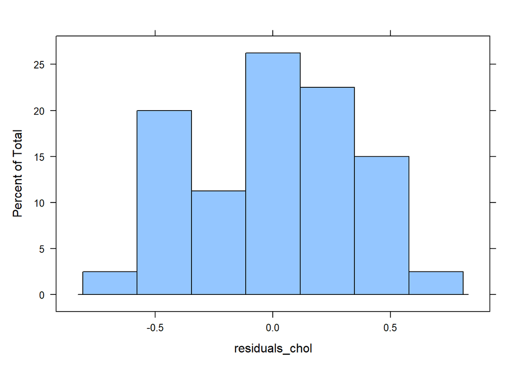

```r
histogram(~ residuals_chol)  # normal
```

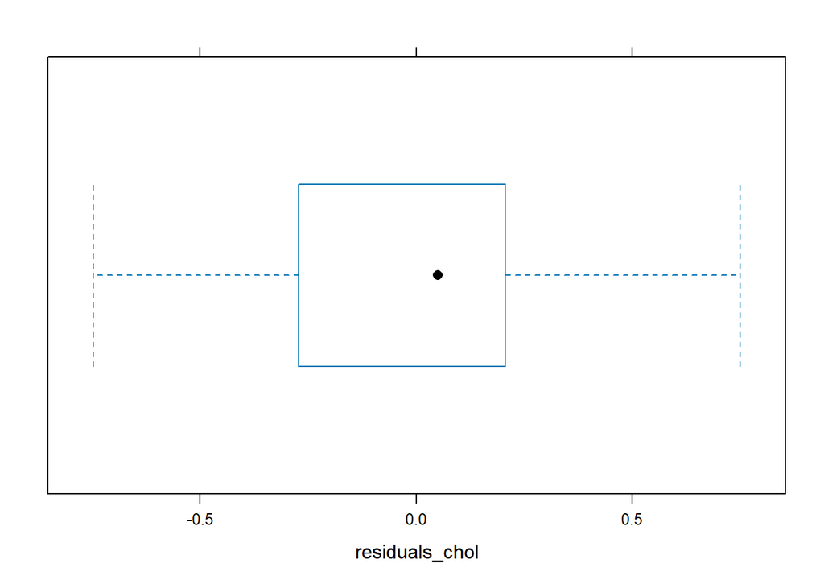

```r
bwplot(~ residuals_chol)
```

## 3.3 Presentation

[Guide: Reporting Statistical Results in Medical Journals](http://www.mjms.usm.my/MJMS23052016/01MJMS23052016_ED.pdf)

# 4 Exercise

- use dataset from “Practice Datasets” folder